# Exercise 5: Nonparametric IRT in R

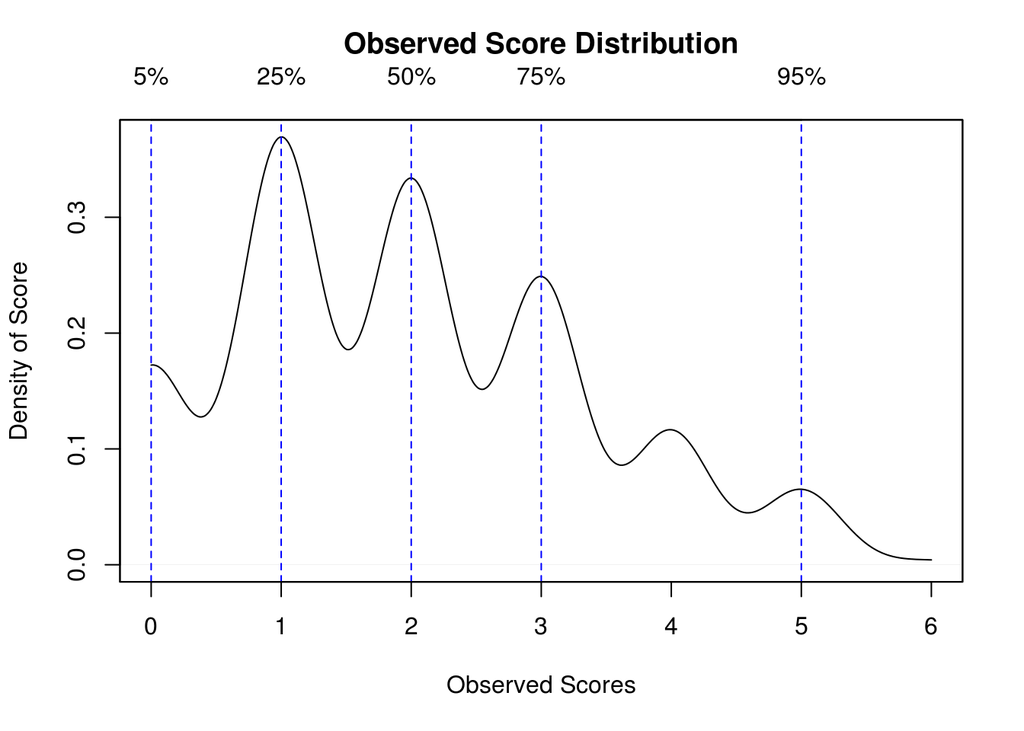

```r
plot(ksm,plottype="density")
```

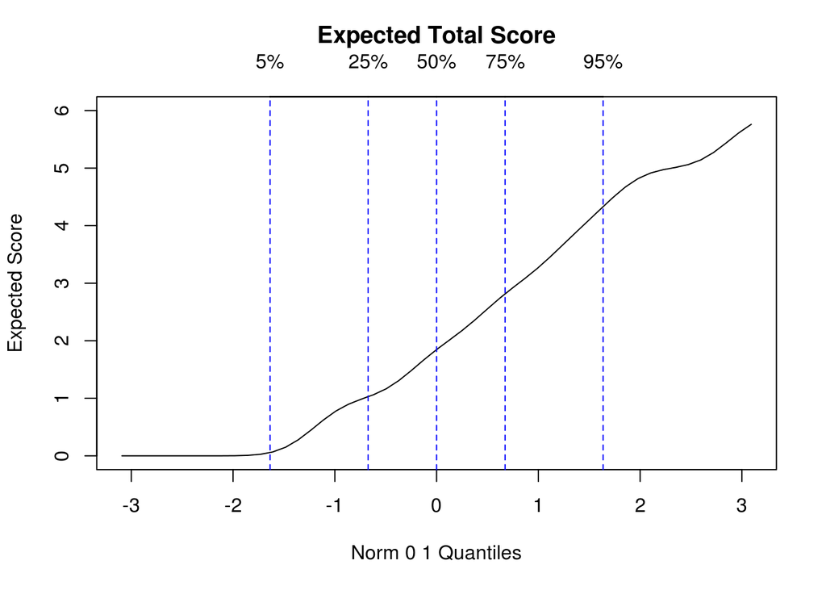

```r
plot(ksm,plottype="expected")
```

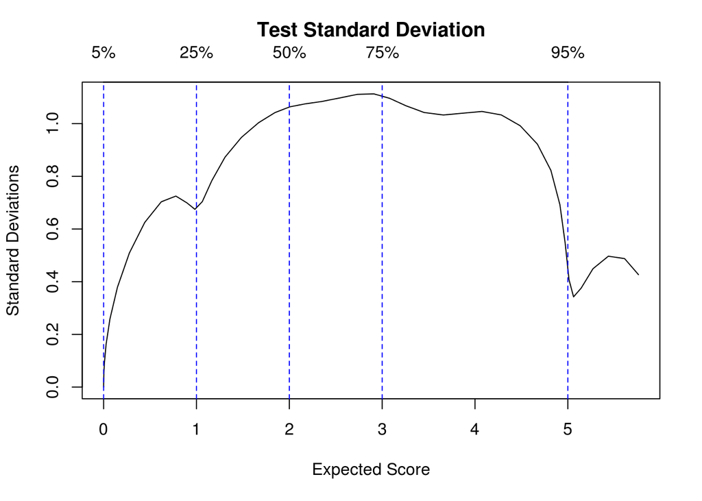

```r
plot(ksm,plottype="sd")
```

7. BONUS: Investigate the relative credibility for the first person from each raw score group (`plottype="RCC"`). This is essentially giving the posterior distribution of the scores a subject should have had (in black) while in red is the real score. How good is the credibility for scores 3, 4, 5? (Hint: The people are ordered based on raw score).

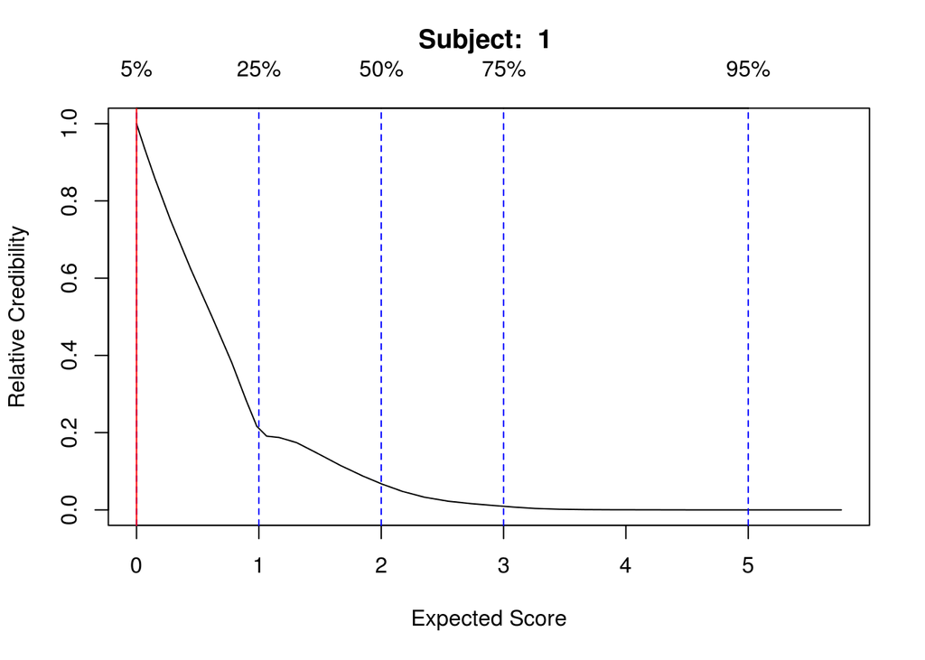

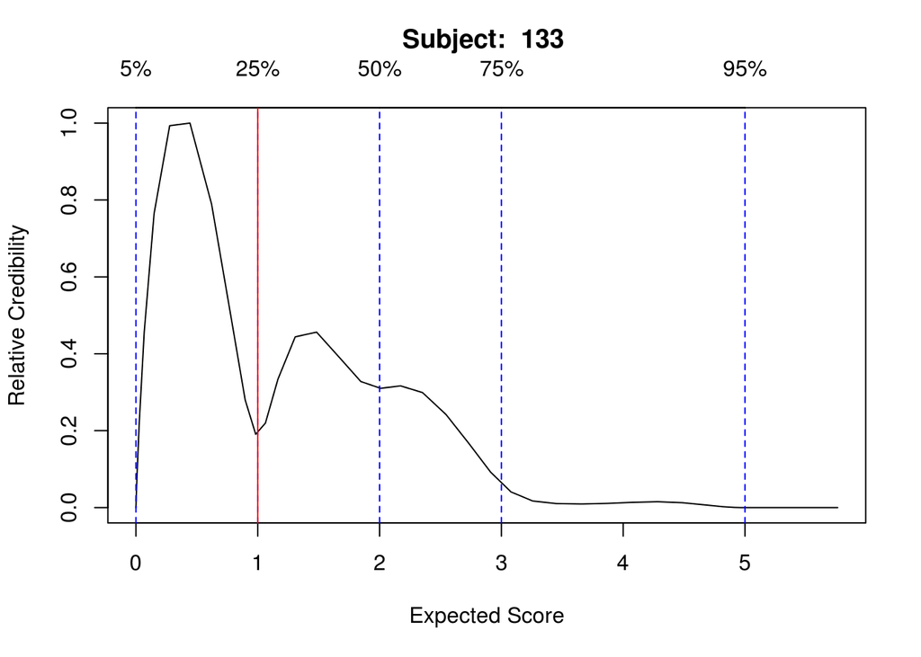

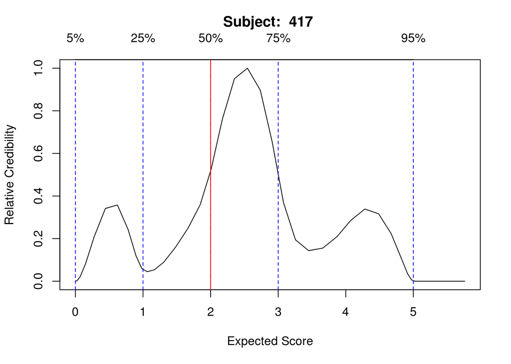

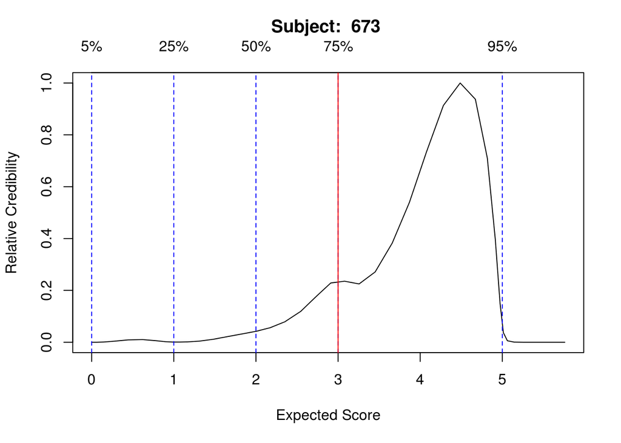

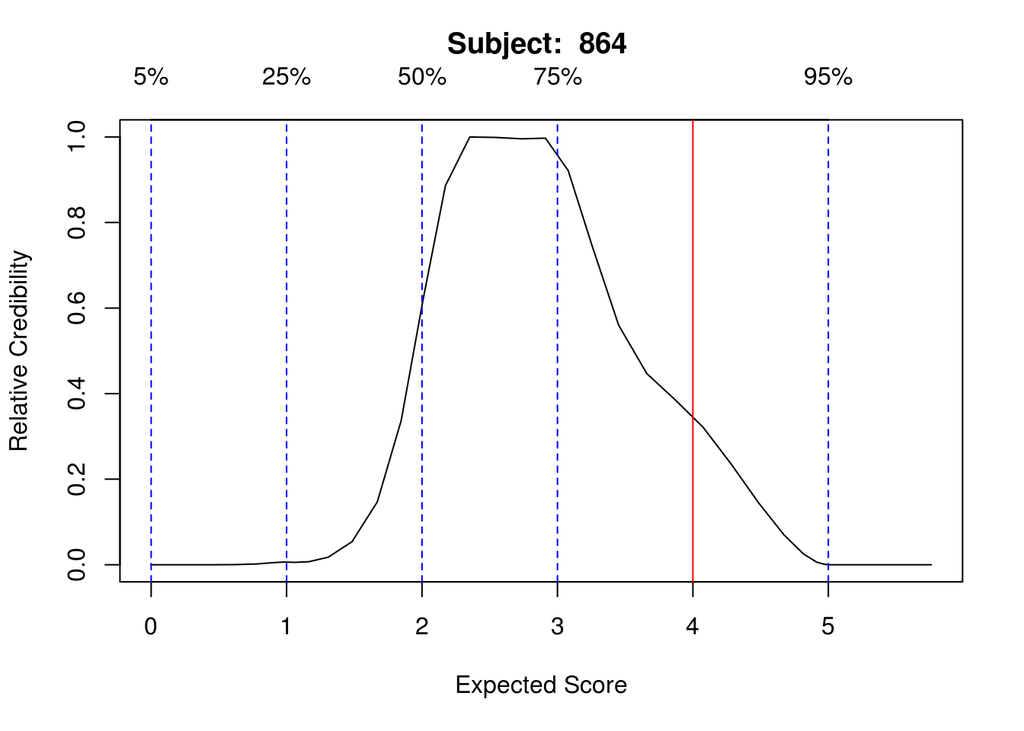

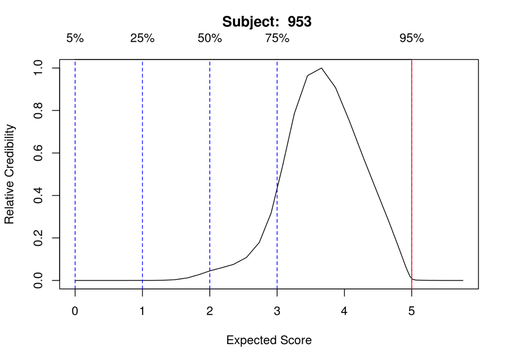

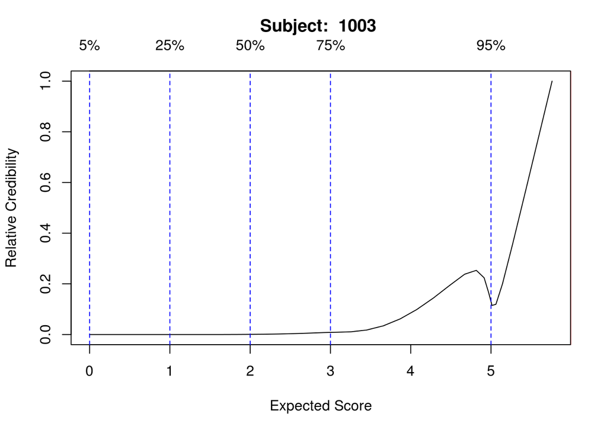

```r
p0<- which(rowSums(WIRS)==0)[1]
p1<- which(rowSums(WIRS)==1)[1]
p2<- which(rowSums(WIRS)==2)[1]
p3<- which(rowSums(WIRS)==3)[1]
p4<- which(rowSums(WIRS)==4)[1]
p5<- which(rowSums(WIRS)==5)[1]
p6<- which(rowSums(WIRS)==6)[1]

plot(ksm,plottype="RCC",subjects=c(p0,p1,p2,p3,p4,p5,p6))
```

This work is licensed under a [Creative Commons Attribution-ShareAlike 4.0 International License](http://creativecommons.org/licenses/by-sa/4.0/).